# Project 2 - Non-Technical Report

Douglas Barley, Rachel Greenlee, Sean Connin

5/9/2022

## Executive Summary

The FDA issued new regulations related to the pH levels in beverage manufacturing that require companies to understand and monitor manufacturing factors that influence pH levels in their products. The Data Science team at ABC Beverage was tasked to develop a model that will assist Manufacturing Operations to better understand and control pH levels in our products. Their results show that there are four discrete manufacturing processes that contribute to pH levels, and the formula for controlling pH is included in this report, along with next steps for each of the teams involved.

## The Issue

ABC Beverage has become aware of new regulations that require us to understand our manufacturing process in terms of how pH variance is affected. This includes the predictive factors that impact pH, as well as a clear understanding of our predictive model of pH.

## Understanding manufacturing factors that impact pH

Based on the metrics that our Manufacturing Operations teams regularly collect throughout the manufacturing process, our team of data scientists evaluated a set of machine learning models to predict pH. Due to the quality of the data, the models that were tested were robust to both missing values and outliers.

The following predictive models were trained and evaluated:

- Basic Decision Tree
- Random Forest
- Support Vector Machine (SVM)
- Neural Net (single layer, forward) (NNET)
- Multivariate Adaptive Regression Splines (MARS)

For those who may be interested in knowing more about the modeling process that was utilized, additional details are available in the Technical Report. Please contact the data science team members directly to request a copy of it.

The data science team focused its efforts around model parameter optimization and model selection using the industry standard technique of 10-fold cross-validation, and as a result they identified the manufacturing components that can help us as a company better understand and identify issues that impact pH levels.

## Predictive Factors

Our Data Science team used the RMSE (root mean squared error) metric to evaluate/compare the models’ performance. The lowest RMSE and smallest standard error indicate the preferred model, which according to the Estimate column in Table 1 is clearly the MARS model.

```r
 # list best rmse results by model

collect_metrics(grid.results)%>%
  filter(.metric == c("rmse"))%>%
  dplyr::select(model, .metric, mean, .config) %>%
  group_by(model)%>%
  slice(which.min(mean))%>%
  rename(c(Model = model, Estimate = 'mean', 'CV-Fold' = .config))%>%
  mutate(Metric = 'RMSE')%>%
  relocate(Metric, .after=Model)%>%
  mutate(Model = ifelse(Model %in% 'rand_forest', 'Random Forest', Model))%>%
  mutate(Model = ifelse(Model %in% 'svm_rbf', 'SVM', Model))%>%
  mutate(Model = ifelse(Model %in% 'mlp', 'NNET', Model))%>%
  mutate(Model = ifelse(Model %in% 'decision_tree', 'Decision Tree', Model))%>%
  mutate(Model = ifelse(Model %in% 'mars', 'MARS', Model))%>%
  #mutate(Model = toupper(Model))%>%
  arrange(Estimate)%>%
  select(!.metric)%>%
  flextable()%>%
  set_caption('Table 1. Selected Models Based on Training Fit')
```

Table 1. Selected Models Based on Training Fit

| Model | Metric | Estimate | CV-Fold |
| --- | --- | --- | --- |
| MARS | RMSE | 0.1398617 | Preprocessor1_Model2 |
| Random Forest | RMSE | 0.5177498 | Preprocessor1_Model17 |
| Decision Tree | RMSE | 0.6534581 | Preprocessor1_Model09 |
| SVM | RMSE | 0.6799684 | Preprocessor1_Model18 |
| NNET | RMSE | 0.7011618 | Preprocessor1_Model12 |

This was confirmed with further tests that confirmed MARS as the model of choice. Table 2. shows the results of our model evaluation on test data. It’s clear, based on RMSE scores, that the MARS model outperformed the others. It is also worth noting that the RMSE score for the MARS test data is less than that of the training data, which lends us assurance that the model is not over-fitting the data.

```r
# print table of test fit results

rbind(metrics1, metrics2, metrics3, metrics4, metrics5)%>%
   arrange(Estimate)%>%
   flextable()%>%
   set_caption('Table 2. Comparison of Model Fit on Test Data')
```

Table 2. Comparison of Model Fit on Test Data

| Model | Metric | Estimate |
| --- | --- | --- |
| MARS | rmse | 0.1398370 |
| Neural Network | rmse | 0.8170020 |
| Random Forest | rmse | 0.8347546 |
| SVM | rmse | 0.8579408 |
| Decision Tree | rmse | 0.9389812 |

## Predictive Model of pH

Using the MARS model, Table 3 shows the variables selected for the final model along with their respective coefficients.

```r
# Print model

output<-extract_fit_engine(mars.test)%>%
  summary()

output[12]%>%
  data.frame()%>%
  rownames_to_column(var="Model Components")%>%
  rename(Coefficient = ..y)%>%
  flextable%>%
  set_caption('Table 3. Final MARS Model: Features & Coefficients')
```

Table 3. Final MARS Model: Features & Coefficients

| Model Components | Coefficient |
| --- | --- |
| (Intercept) | 8.465801028 |
| h(0.2-`Mnf Flow`) | 0.001256308 |
| BrandCode_C | -0.112952249 |
| h(`Usage cont`-22.14) | -0.044961352 |
| h(68.2-Temperature) | 0.027763745 |

Therefore, the final model for manufacturing factors that influence pH levels is:

$pH = 8.466+.001*h(0.2-Mnf Flow)$

$-0.113*BrandCode\_C$

$-0.045*h(Usage\_cont-22.14)$

$+0.028*h(68.2-Temperature)$

where *h* = the model `hinge` as shown below graphically in Figure 1.

The hinge is the point where each horizontal line meets a non-horizontal line:

```
## calculating partdep for Mnf Flow
## calculating partdep for Temperature
## calculating partdep for Usage cont
## calculating partdep for BrandCode_C
```

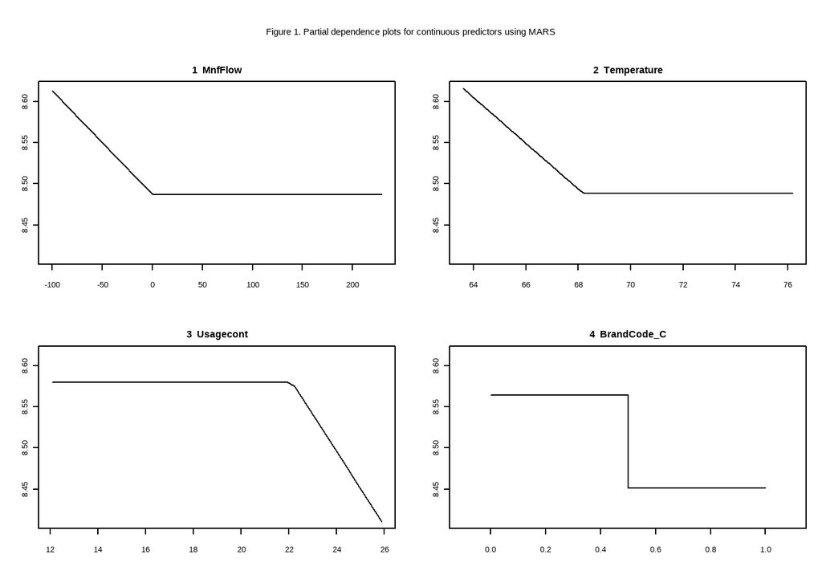

```r
# plot partial dependence of features (from plotmo package in Earth -- plot regression surfaces)

plotmo(output, pmethod='partdep', caption='Figure 1. Partial dependence plots for continuous predictors using MARS')
```

Additionally as seen in Figure 2. we can see how predictions of pH levels tend to converge with actual measurements around the 8.5 level when using the MARS model formula.

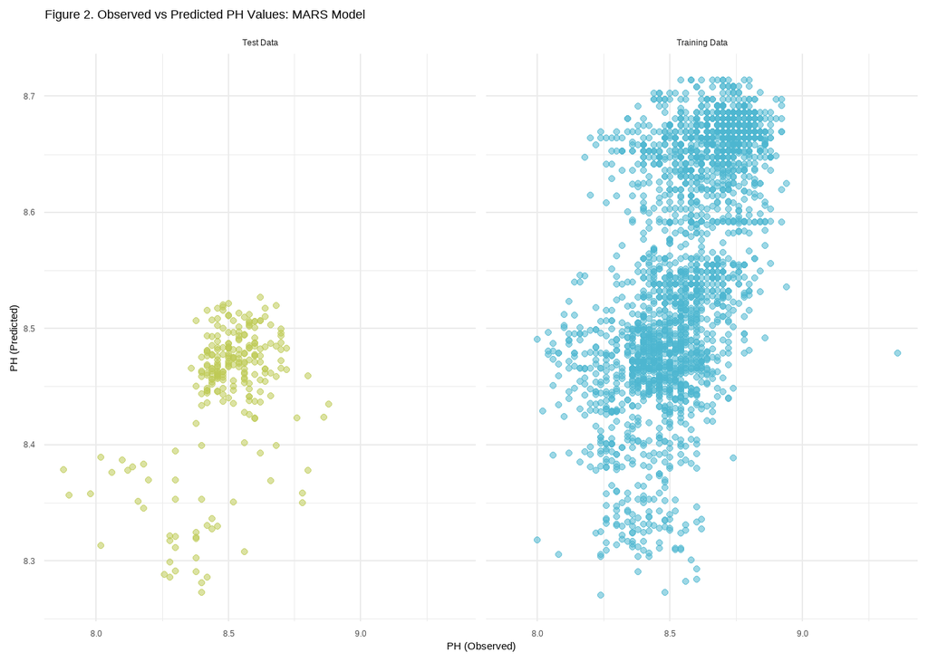

```r
# adapted from https://stackoverflow.com/questions/68124804/tidymodels-get-predictions-and-metrics-on-training-data-using-workflow-recipe

# pull trained workflow

fit.preds <- mars.test$.workflow[[1]]

# augment on test and training data

model.predictions <- bind_rows(
  augment(fit.preds, new_data = test.split) %>%
    mutate(type = "Test Data"),
  augment(fit.preds, new_data = train.split) %>%
    mutate(type = "Training Data"))

# plot observed vs predicted PH for train and test sets

model.predictions %>%
  ggplot(aes(PH, .pred)) +
  geom_point(aes(color=type, alpha=.95), show.legend = FALSE) +
  scale_color_manual(values = c("Training Data" = "#4DB6D0", "Test Data" = "#BECA55"))+
  labs(x='PH (Observed)', y= 'PH (Predicted)', title='Figure 2. Observed vs Predicted PH Values: MARS Model')+
  theme(plot.title = element_text(vjust = 10))+ # this doesn't seem to be working
  theme_minimal() +
  facet_wrap(~type)
```

## Conclusions and Recommendations

The data science team concluded that there are four main manufacturing factors in play in terms of controlling pH in our products. They are shown below with the relative importance of each in Figure 3.

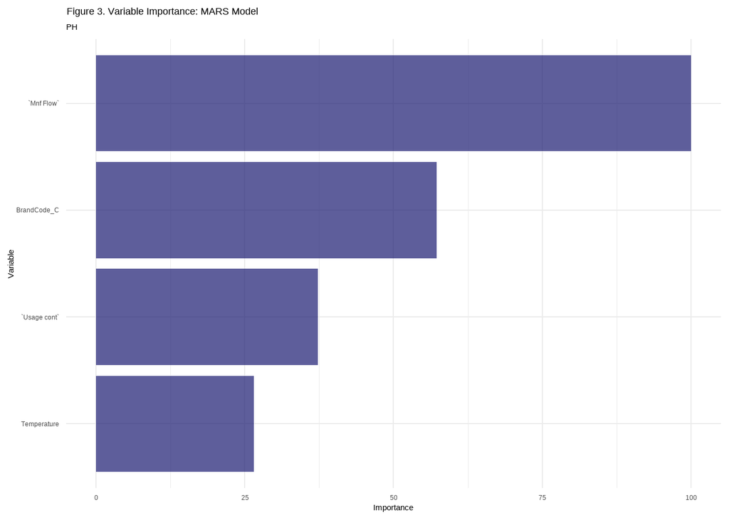

```r
# Plot variable importance for final model and test data

mars.test%>%
  extract_fit_parsnip()%>%
  vi_model(type='gcv')%>% # we can control importance type using vi_model instead of vip
  filter(Importance > 0)%>%
  arrange(desc(Importance))%>%
  mutate(Variable =  factor(Variable), Variable = fct_reorder(Variable, Importance))%>%
  ggplot(aes(x=Importance, y = Variable))+
  geom_col( fill='midnightblue', alpha=0.7)+
  labs(title='Figure 3. Variable Importance: MARS Model', subtitle='PH')+
  theme_minimal()
```

It is recommended that any investments to manipulate pH as part of the manufacturing process should focus on adjustments to these four manufacturing factors, and that a cost/benefit analysis be conducted before committing company resources for any modifications to the manufacturing processes.

## Next Steps

- The Manufacturing Operations team will work with the Finance team to complete a Cost/Benefit analysis focusing on control of the four components of the manufacturing process identified above by the Data Science team.
- The Legal and Government Affairs teams will coordinate reporting of all of our findings to the regulating authority.
- This committee will reconvene within the next 30 days to evaluate the further findings of the Manufacturing Operations and Finance teams.